# 数据分析实战之AQI分析与预测

## 分析背景

AQlI（Air Quality Index），指空气质量指数，用来衡量空气清洁或污染的程度。值越小，表示空气质量越好。近年来，因为环境问题，空气质量也越来越受到人们的重视。

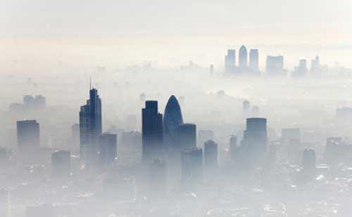

## 提出分析问题

- 哪些城市的空气质量较好/较差？【描述性统计分析】
- 空气质重在地理位置分布上，是否具有一定的规律性？【描述性统计分析】
- 临海城市的空气质量是否有别于内陆城市？【推断统计分析】
- 空气质量主要受哪些因素影响？【相关系数分析】
- 全国城市空气质量普遍处于何种水平？【区间估计】
- 怎样预测一个城市的空气质量？【统计建模】

其中，描述性统计分析属于探索型数据分析，推断统计分析属于验证型数据分析，统计建模属于预测性数据分析

## 数据理解

已获取了2015年空气质量指数集。该数据集包含全国主要城市的相关数据以及空气质量指数。相关字段信息见下表：

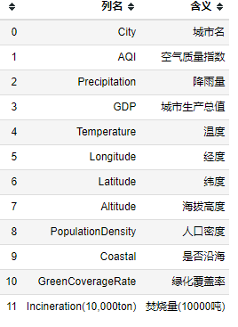

## 导入相关库

导入库，同时进行一些初始化设置

```python
import numpy as np
import pandas as pd
import matplotlib.pyplot as plt
import seaborn as sns
import warnings
```

```python
warnings.filterwarnings('ignore')#忽略警告信息
sns.set(style='darkgrid',color_codes=True,context='notebook',font='SimHei',rc={"axes.unicode_minus":False})#设置绘图格式，便于显示中文
```

## 获取数据，加载相关数据集

- 加载相关数据集
- 使用head,tail,sample（info）查看数据大概情况

```python
data = pd.read_csv('data.csv',encoding='utf8') #导入数据
```

```python
data.columns #查看数据的所有字段
```

```
Index(['City', 'AQI', 'Precipitation', 'GDP', 'Temperature', 'Longitude',
       'Latitude', 'Altitude', 'PopulationDensity', 'Coastal',
       'GreenCoverageRate', 'Incineration(10,000ton)'],
      dtype='object')
```

```python
v1 = list(data.columns) #转化为列表
```

```python
v2 = ['城市名','空气质量指数','降雨量','城市生产总值','温度','经度','纬度','海拔高度','人口密度','是否沿海','绿化覆盖率','焚烧量(10000吨)']
```

```python
info = pd.DataFrame({'列名':v1,'含义':v2}) #构造info信息表便于后续查看
```

```python
info
```

|  | 列名 | 含义 |
| --- | --- | --- |
| 0 | City | 城市名 |
| 1 | AQI | 空气质量指数 |
| 2 | Precipitation | 降雨量 |
| 3 | GDP | 城市生产总值 |
| 4 | Temperature | 温度 |
| 5 | Longitude | 经度 |
| 6 | Latitude | 纬度 |
| 7 | Altitude | 海拔高度 |
| 8 | PopulationDensity | 人口密度 |
| 9 | Coastal | 是否沿海 |
| 10 | GreenCoverageRate | 绿化覆盖率 |
| 11 | Incineration(10,000ton) | 焚烧量(10000吨) |

```python
data.info() #查看数据大致信
```

```
<class 'pandas.core.frame.DataFrame'>
RangeIndex: 325 entries, 0 to 324
Data columns (total 12 columns):
City                       325 non-null object
AQI                        325 non-null int64
Precipitation              321 non-null float64
GDP                        325 non-null float64
Temperature                325 non-null float64
Longitude                  325 non-null float64
Latitude                   325 non-null float64
Altitude                   325 non-null float64
PopulationDensity          325 non-null int64
Coastal                    325 non-null int64
GreenCoverageRate          325 non-null float64
Incineration(10,000ton)    325 non-null float64
dtypes: float64(8), int64(3), object(1)
memory usage: 30.6+ KB
```

```python
len(data)
```

```
325
```

```python
#查看数据头五条
data.head()
```

|  | City | AQI | Precipitation | GDP | Temperature | Longitude | Latitude | Altitude | PopulationDensity | Coastal | GreenCoverageRate | Incineration(10,000ton) |
| --- | --- | --- | --- | --- | --- | --- | --- | --- | --- | --- | --- | --- |
| 0 | Ngawa Prefecture | 23 | 665.1 | 271.13 | 8.200000 | 102.224650 | 31.899410 | 2617.0 | 11 | 0 | 36.00 | 23.00 |
| 1 | Aksu City | 137 | 80.4 | 610.00 | 12.276712 | 80.263380 | 41.167540 | 1108.0 | 6547 | 0 | 33.94 | 23.00 |
| 2 | Alxa League | 85 | 150.0 | 322.58 | 24.200000 | 105.728950 | 38.851920 | 1673.0 | 1 | 0 | 36.00 | 23.00 |
| 3 | Ngari | 28 | 74.2 | 37.40 | 1.000000 | 80.105800 | 32.501110 | 4280.0 | 1 | 0 | 36.00 | 23.00 |
| 4 | Anqin City | 79 | 2127.8 | 1613.20 | 17.291781 | 117.034431 | 30.512646 | 13.0 | 2271 | 0 | 45.80 | 27.48 |

```python
#查看数据后五条
data.tail()
```

|  | City | AQI | Precipitation | GDP | Temperature | Longitude | Latitude | Altitude | PopulationDensity | Coastal | GreenCoverageRate | Incineration(10,000ton) |
| --- | --- | --- | --- | --- | --- | --- | --- | --- | --- | --- | --- | --- |
| 320 | Zhumadian City | 79 | 1388.0 | 1807.09 | 15.946575 | 114.035690 | 32.979042 | 84.0 | 2539 | 0 | 39.46 | 18.86 |
| 321 | Ziyang City | 86 | 807.8 | 1270.40 | 16.182192 | 104.650190 | 30.122671 | 367.0 | 1787 | 0 | 38.67 | 18.28 |
| 322 | Zibo City | 116 | 288.0 | 4130.20 | 14.576712 | 118.056053 | 36.793579 | 38.0 | 782 | 0 | 36.00 | 31.00 |
| 323 | Zigong City | 118 | 994.8 | 1143.11 | 19.432877 | 104.776352 | 29.367722 | 311.0 | 1557 | 0 | 40.20 | 35.47 |
| 324 | Zunyi City | 60 | 1000.0 | 2168.34 | 16.991781 | 106.929398 | 27.695387 | 865.0 | 3581 | 0 | 44.06 | 34.51 |

## 数据清洗

在进行分析前需要对原来的数据进行清洗，具体包括缺失值和异常值处理和重复值处理

- 缺失值处理
- 异常值处理
- 重复值处理

### 缺失值处理

根据情况使用平均值，中位数，众数，以及拉格朗日差值进行填充，或者删除缺失值

```python
#查看是否有缺失值
data.info()
```

```
<class 'pandas.core.frame.DataFrame'>
RangeIndex: 325 entries, 0 to 324
Data columns (total 12 columns):
City                       325 non-null object
AQI                        325 non-null int64
Precipitation              321 non-null float64
GDP                        325 non-null float64
Temperature                325 non-null float64
Longitude                  325 non-null float64
Latitude                   325 non-null float64
Altitude                   325 non-null float64
PopulationDensity          325 non-null int64
Coastal                    325 non-null int64
GreenCoverageRate          325 non-null float64
Incineration(10,000ton)    325 non-null float64
dtypes: float64(8), int64(3), object(1)
memory usage: 30.5+ KB
```

数据一共325行，可得出Precipitation列有缺失值，我们使用中位数（因为影响降雨量的因素较多）进行填充，并查看删除缺失值与填充后的数据分布情况

```python
#使用isnull,notnull查看缺失值存在的行数
data[data['Precipitation'].isnull() == True]
```

|  | City | AQI | Precipitation | GDP | Temperature | Longitude | Latitude | Altitude | PopulationDensity | Coastal | GreenCoverageRate | Incineration(10,000ton) |
| --- | --- | --- | --- | --- | --- | --- | --- | --- | --- | --- | --- | --- |
| 17 | Benxi City | 63 | NaN | 1160.00 | 9.271233 | 123.764503 | 41.287586 | 100.0 | 602 | 0 | 44.88 | 31.76 |
| 84 | Huaibei City | 97 | NaN | 760.40 | 16.197260 | 116.787499 | 33.970489 | 32.0 | 3883 | 0 | 43.94 | 21.75 |
| 134 | Lianyungang City | 65 | NaN | 2160.64 | 14.176712 | 119.166801 | 34.605179 | 4.0 | 1463 | 1 | 40.92 | 36.25 |
| 201 | Shangqiu City | 65 | NaN | 1803.93 | 15.054795 | 115.647186 | 34.443584 | 50.0 | 9364 | 0 | 36.06 | 28.17 |

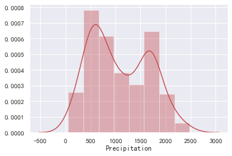

```python
#使用密度图查看分布情况
sns.distplot(data['Precipitation'].dropna(),color='r')
plt.show()
```

```python
#对数据进行填充
data['Precipitation'].fillna(data['Precipitation'].median(),inplace=True)
```

```python
#查看是否替换
data.info()
```

```
<class 'pandas.core.frame.DataFrame'>
RangeIndex: 325 entries, 0 to 324
Data columns (total 12 columns):
City                       325 non-null object
AQI                        325 non-null int64
Precipitation              325 non-null float64
GDP                        325 non-null float64
Temperature                325 non-null float64
Longitude                  325 non-null float64
Latitude                   325 non-null float64
Altitude                   325 non-null float64
PopulationDensity          325 non-null int64
Coastal                    325 non-null int64
GreenCoverageRate          325 non-null float64
Incineration(10,000ton)    325 non-null float64
dtypes: float64(8), int64(3), object(1)
memory usage: 30.5+ KB
```

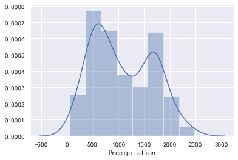

```python
#缺失值已被替换，查看数据分布
sns.distplot(data['Precipitation'],color='b')
plt.show()
```

### 异常值处理

- 使用describe查看数据
- 辅助使用箱形图查看分布情况

```python
data.describe()
```

|  | AQI | Precipitation | GDP | Temperature | Longitude | Latitude | Altitude | PopulationDensity | Coastal | GreenCoverageRate | Incineration(10,000ton) |
| --- | --- | --- | --- | --- | --- | --- | --- | --- | --- | --- | --- |
| count | 325.000000 | 325.0000 | 325.000000 | 325.000000 | 325.000000 | 325.000000 | 325.000000 | 325.000000 | 325.000000 | 325.000000 | 325.000000 |
| mean | 75.809231 | 1079.3520 | 2390.901815 | 15.980149 | 113.990609 | 31.870665 | 380.141846 | 2610.883077 | 0.246154 | 38.347969 | 52.315108 |
| std | 43.610516 | 583.5252 | 3254.876921 | 5.016133 | 7.688515 | 6.093703 | 741.409703 | 2910.679547 | 0.431433 | 6.319706 | 91.707838 |
| min | 12.000000 | 56.1000 | 22.500000 | -2.500000 | 80.105800 | 18.234043 | -12.000000 | 1.000000 | 0.000000 | 7.600000 | 1.530000 |
| 25% | 45.000000 | 581.0000 | 762.970000 | 13.727397 | 111.130000 | 27.695387 | 18.000000 | 721.000000 | 0.000000 | 35.530000 | 18.890000 |
| 50% | 69.000000 | 920.0000 | 1328.520000 | 16.494521 | 115.500183 | 31.385597 | 62.000000 | 1790.000000 | 0.000000 | 38.690000 | 24.000000 |
| 75% | 102.000000 | 1651.0000 | 2735.340000 | 18.921918 | 119.823308 | 36.449432 | 354.000000 | 3517.000000 | 0.000000 | 42.620000 | 37.630000 |
| max | 296.000000 | 2478.1000 | 24964.990000 | 27.447945 | 129.598496 | 49.220000 | 4505.000000 | 25900.000000 | 1.000000 | 76.490000 | 686.670000 |

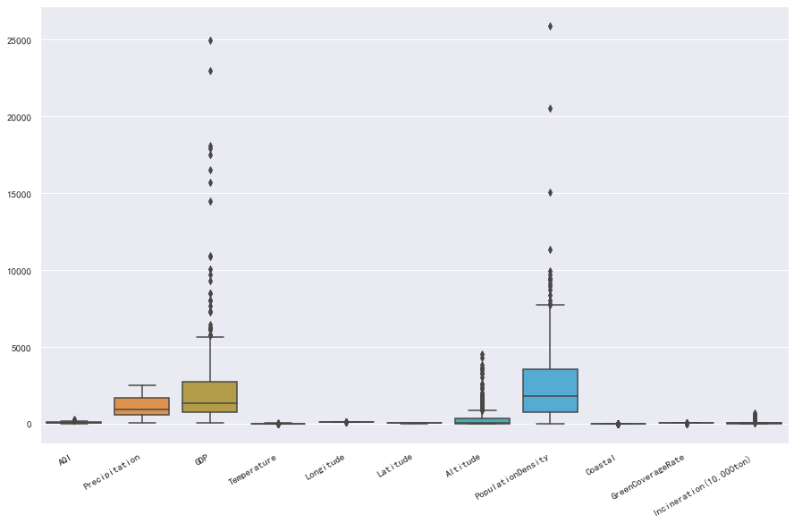

```python
#使用箱形图查看总体数据分布
f,ax = plt.subplots(figsize=(15,10))
sns.boxplot(data=data)
f.autofmt_xdate()
```

分位数的计算：

1. 四分之一分位数：Q1=(n+1)*0.25
2. 中位数：Q2=(n+1)*0.5
3. 四分之三分位数：Q3=(n+1)*0.75

四分位距=Q3-Q1 上限：Q3+1.5*四分位距， 下界：Q1-1.5*四分位距

```python
#设置异常值区间，规定1.5倍的上下四分位数为界限

#获取数据，将异常值数据改为非异常值数据
def y_c(data):
    data_n = data.copy(deep=True)#复制一份新的
    for col in data_n:
        if pd.api.types.is_numeric_dtype(data_n[col]):#判断为数值型变量才进行计算
            o = data_n[col].describe()
            IQR = o['75%'] - o['25%']
            lower = o['25%'] - 1.5 * IQR
            upper = o['75%'] + 1.5 * IQR

            data_n[col][data_n[col] < lower] = lower
            data_n[col][data_n[col] > upper] = upper

    return data_n

t = y_c(data)
```

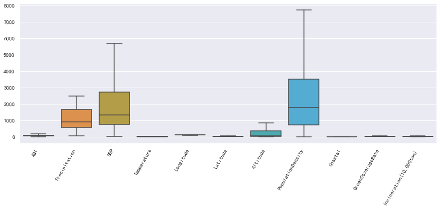

```python
#可视化数据查看分布
f,aex = plt.subplots(figsize = (15,5))
sns.boxplot(data = t)
f.autofmt_xdate(bottom=0.1, rotation=60, ha='right', which=None)#bottom控制长宽比例，rotation控制斜度，ha控制显示方向，默认配置即可
```

### 重复值处理

- ·使用duplicate检查重复值。可配合keep参数进行调整。
- ·使用drop_duplicate]除重复值。

```python
#发现重复值
# data = data.copy(deep=True)
data.duplicated().sum()
```

```
2
```

```python
#查看那些记录出现了重复值
data[data.duplicated()]
```

[output not shown]

```python
#去除重复值
data.drop_duplicates(inplace=True)
```

```python
#检查是否还有重复值
data.duplicated().sum()#结果为0，重复值已经去除
```

```
0
```

## 数据分析

### 空气质量最好/最差的5个城市

可以作为未来选取居住地的参考标准

```python
#查看info表
info
```

|  | 列名 | 含义 |
| --- | --- | --- |
| 0 | City | 城市名 |
| 1 | AQI | 空气质量指数 |
| 2 | Precipitation | 降雨量 |
| 3 | GDP | 城市生产总值 |
| 4 | Temperature | 温度 |
| 5 | Longitude | 经度 |
| 6 | Latitude | 纬度 |
| 7 | Altitude | 海拔高度 |
| 8 | PopulationDensity | 人口密度 |
| 9 | Coastal | 是否沿海 |
| 10 | GreenCoverageRate | 绿化覆盖率 |
| 11 | Incineration(10,000ton) | 焚烧量(10000吨) |

```python
#空气质量由ＡＱＩ指标来很衡量，对其进行排序
data[['City','AQI']].head()
```

|  | City | AQI |
| --- | --- | --- |
| 0 | Ngawa Prefecture | 23 |
| 1 | Aksu City | 137 |
| 2 | Alxa League | 85 |
| 3 | Ngari | 28 |
| 4 | Anqin City | 79 |

```python
data[['City','AQI']].sort_values(by = "AQI",ascending=False).head(5)#获取前五名
```

|  | City | AQI |
| --- | --- | --- |
| 16 | Beijing City | 296 |
| 26 | Chaoyang City | 224 |
| 13 | Baoding City | 220 |
| 112 | Jinzhou City | 202 |
| 105 | Jiaozuo City | 199 |

```python
data[['City','AQI']].sort_values(by = "AQI",ascending=False).tail(5)#获取后五名
```

|  | City | AQI |
| --- | --- | --- |
| 91 | Keelung City | 13 |
| 195 | Sanming City | 13 |
| 204 | Shaoguan City | 12 |
| 154 | Meizhou City | 12 |
| 163 | Nanping City | 12 |

```python
#柱状图显示分布
five_f = data[['City','AQI']].sort_values(by = "AQI",ascending=False).head(5)#获取前五名
five_l = data[['City','AQI']].sort_values(by = "AQI",ascending=False).tail(5)#获取后五名
```

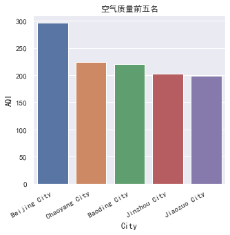

```python
f,aex = plt.subplots(figsize=(5,5))
sns.barplot(x='City',y='AQI',data=five_f)
# f.autofmt_xdate()
f.autofmt_xdate()
aex.set_title('空气质量前五名')
plt.show()
```

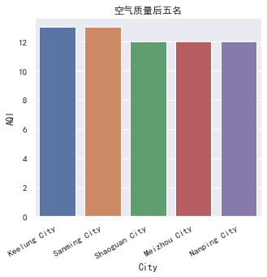

```python
f,aex = plt.subplots(figsize=(5,5))
sns.barplot(x='City',y='AQI',data=five_l)
# f.autofmt_xdate()
f.autofmt_xdate()
aex.set_title('空气质量后五名')
plt.show()
```

### 空气质量和地理位置存在的关系探索

```python
info
```

|  | 列名 | 含义 |
| --- | --- | --- |
| 0 | City | 城市名 |
| 1 | AQI | 空气质量指数 |
| 2 | Precipitation | 降雨量 |
| 3 | GDP | 城市生产总值 |
| 4 | Temperature | 温度 |
| 5 | Longitude | 经度 |
| 6 | Latitude | 纬度 |
| 7 | Altitude | 海拔高度 |
| 8 | PopulationDensity | 人口密度 |
| 9 | Coastal | 是否沿海 |
| 10 | GreenCoverageRate | 绿化覆盖率 |
| 11 | Incineration(10,000ton) | 焚烧量(10000吨) |

```python
data.head()
```

|  | City | AQI | Precipitation | GDP | Temperature | Longitude | Latitude | Altitude | PopulationDensity | Coastal | GreenCoverageRate | Incineration(10,000ton) |
| --- | --- | --- | --- | --- | --- | --- | --- | --- | --- | --- | --- | --- |
| 0 | Ngawa Prefecture | 23 | 665.1 | 271.13 | 8.200000 | 102.224650 | 31.899410 | 2617.0 | 11 | 0 | 36.00 | 23.00 |
| 1 | Aksu City | 137 | 80.4 | 610.00 | 12.276712 | 80.263380 | 41.167540 | 1108.0 | 6547 | 0 | 33.94 | 23.00 |
| 2 | Alxa League | 85 | 150.0 | 322.58 | 24.200000 | 105.728950 | 38.851920 | 1673.0 | 1 | 0 | 36.00 | 23.00 |
| 3 | Ngari | 28 | 74.2 | 37.40 | 1.000000 | 80.105800 | 32.501110 | 4280.0 | 1 | 0 | 36.00 | 23.00 |
| 4 | Anqin City | 79 | 2127.8 | 1613.20 | 17.291781 | 117.034431 | 30.512646 | 13.0 | 2271 | 0 | 45.80 | 27.48 |

### 城市空气质量等级统计

国家对空气质量进行等级划分，划分标准如下：

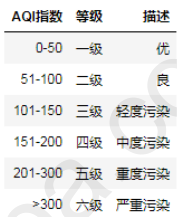

```python
#根据AQI指数对全国各城市的空气质量进行等级划分
first = len(data[(data['AQI'] >=0) & (data['AQI'] <=50)])
second = len(data[(data['AQI'] >=51) & (data['AQI'] <=100)])
third = len(data[(data['AQI'] >=101) & (data['AQI'] <=150)])
fourth = len(data[(data['AQI'] >=151) & (data['AQI'] <=200)])
fifth = len(data[(data['AQI'] >=201) & (data['AQI'] <=300)])
sixth = len(data[data['AQI'] >300])
pai_num = [first,second,third,fourth,fifth,sixth]
pai_grade = ['优','良','轻度污染','中度污染','重度污染','严重污染']
```

```python
fenbu = pd.DataFrame({'grade':pai_grade,'count':pai_num})
```

```python
fenbu
```

|  | grade | count |
| --- | --- | --- |
| 0 | 优 | 103 |
| 1 | 良 | 136 |
| 2 | 轻度污染 | 66 |
| 3 | 中度污染 | 14 |
| 4 | 重度污染 | 4 |
| 5 | 严重污染 | 0 |

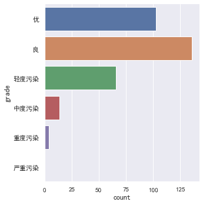

```python
#画出空气质量分布图
sns.catplot(y = 'grade',x = 'count',kind='bar',data=fenbu,height=5)
plt.show()
```

可见，我们的城市的空气质量指数主要是以优良为主，轻度污染占一部分，污染很严重的很少

### 空气质量指数分布

我们来绘制下全国空气质量分布图，以经度纬度作为判定依据

```python
# info
```

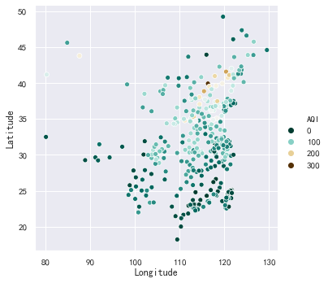

```python
sns.relplot(x='Longitude',y='Latitude',hue='AQI',data=data,palette='BrBG_r')
```

从结果我们可以发现，从大致的地理位置上看，西部城市好于东部城市，南部城市好于北部城市。

```python
len(data[data['Coastal']==0])
```

```
243
```

### 关于空气质量的验证

- 江湖传闻，全国所有城市的空气质量指数均值在72左右，请问，这个消息可靠吗？
- 城市平均空气质量指数，我们可以很容易的进行计算。

```python
#计算均值
data['AQI'].mean()
```

```
75.3343653250774
```

- 首先，我们要清楚，江湖传闻的，是全国所有城市的平均空气质量指数，而我们统计的，只是所有城市中的一部分抽样而已。因此，我们一次抽样统计的均值，并不能代表总体（所有城市）的均值。
- 要弄清江湖传闻是否可靠，最直接有效的方式，就是将全国所有的城市的空气质量指数都测量一下，然后进行求均值。然而，这是非常繁重且不现实的任务。因此，可行的方案是，我们从全国所有城市中进行抽样，使用抽样的均值来估计总体的均值。

#### 中心极限定理

根据中心极限定理可得：

1. 进行多次抽样，则每次抽样会得到一个均值，这些均值会围绕在总体均值左右，呈正态分布。
2. 当样本容量n足够大时，样本均值服从正态分布。样本均值构成的正态分布，其均值等于总体均值μ。
3. 样本均值构成的正态分布，其标准差等于总体标准差除以n的二分之一次方。说明：样本均值分布的标准差，称为标准误差，简称标准误。

#### 置信区间

接下来根据正态分布吧的特性进行概率统计，如下图

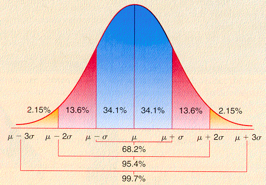

在正态分布中，数据的分布比例如下：

- 以均值为中心，在一倍标准差内，包含约68%的样本数据。
- 以均值为中心，在二倍标准差内，包含约95%的样本数据。
- 以均值为中心，在三倍标准差内，包含约99.7%的样本数据。

```python
#定义标准差
scale = 30
#定义数据
x = np.random.normal(0,scale,size=100000) #构造正太分布的数据，均值为0，标准差为30，一共有10万个数据
#定义标准差的倍数，倍数从1到3
for times in range(1,4):
    y = x[(x >= -times * scale) & (x <= times * scale)]
    print(str(times)+'倍标准差为：')
    print(f"{len(y)*100 /len(x)}%")
```

```
1倍标准差为：
68.121%
2倍标准差为：
95.425%
3倍标准差为：
99.729%
```

1. 根据中心极限定理，如果多次抽样，则样本均值构成的正态分布。如果我们对总体进行一次抽样，则本次抽样个体的均值有95%的概率会在二倍标准差内，仅有5%的概率会在二倍标准差外。根据小概率事件（很小的概率在一次抽样中基本不会发生），如果抽样的个体均值落在二倍标准差之外，我们就可以认为，本次抽样来自的总体，该总体的均值并非是我们所期望的均值。
2. 通常，我们以二倍标准差作为判定依据，则以均值为中心，正负二倍标准差构成的区间，就是置信区间。而二倍标准差包含了95%的数据，因此，此时的置信度为95%。换言之，我们有信心认为，总体的均值有95%的概率会在置信区间之内。

#### 假设检验——t检验

- 假设检验，其目的是通过收集到的数据，来验证某个假设是否成立。在假设检验中，我们会建立两个完全对立的假设，分别为原假设（零假设）H0与备则假设（对立假设）H1。然后根据样本信息进行分析判断，得出P值（概率值）。
- 假设检验基于小概率反证法，即我们认为小概率事件在一次试验中是不会发生的。如果小概率事件发生，则我们就拒绝原假设，而接受备择假设。否则，我们就没有充分的理由推翻原假设，此时，我们选择去接受原假设。
- t检验，就是假设检验的一种，可以用来检验一次抽样中样本均值与总体均值的比较（二者差异是否显著）。其计算方式如下：

```python
#进行T检验
# 我们所得样本均值为75.33 > 72,所以设置原假设为H0 = 75.33 > 72，备择假设H1为全国空气质量平均值小于72，采用单侧检验
from scipy import stats

result = stats.ttest_1samp(data['AQI'],72)
print("t值",result.statistic) #t值为检验统计量
print("P值",result.pvalue)#p-value：检验统计量出现当前值或者更为极端的值的概率
```

```
t值 1.393763441074581
P值 0.16435019471704654
```

```python
#下面来算算空气质量的置信区间
n = len(data)
df = n - 1
left = stats.t.ppf(0.025,df = df )
right = stats.t.ppf(0.095,df = df )

print(left,right)
mean = data['AQI'].mean()
std = data['AQI'].std()
mean + left * (std / np.sqrt(n)),mean + right * (std / np.sqrt(n)) #sqrt求n的开方,输出置信区间
```

```
-1.9673585853224684 -1.313350335082628
```

```
(70.6277615675309, 72.19237602623198)
```

### 临海城市是否空气质量优于内陆城市？

我们首先来统计下临海城市与内陆城市的数量。

```python
# info使用display函数l
display(data["Coastal"].value_counts())
```

```
0    243
1     80
Name: Coastal, dtype: int64
```

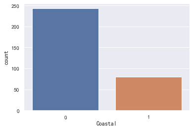

```python
#柱状图显示
sns.countplot(x='Coastal',data=data)
plt.show()
```

然后观察临海城市与内陆城市散点分布

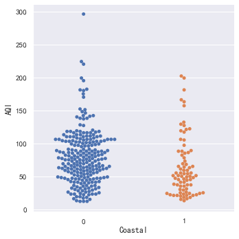

```python
#查看沿海城市与非沿海城市的ＡＱＩ差异
sns.catplot(x='Coastal',y='AQI',kind='swarm',data=data)
plt.show()
```

然后分组计算空气质量的均值

```python
data.groupby('Coastal')['AQI'].mean()
```

```
Coastal
0    79.045267
1    64.062500
Name: AQI, dtype: float64
```

```python
# data.groupby('Coastal').get_group(0)
```

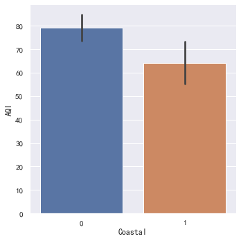

```python
sns.catplot(x='Coastal',y='AQI',kind='bar',data=data)
plt.show()
```

在柱形图中，仅显示了内陆城市与临海城市空气质量指数（AQl）的均值对比，我们可以使用箱线图来显示更多的信息。

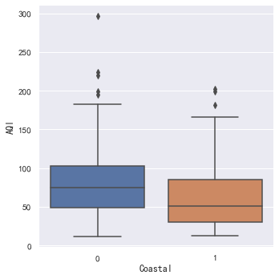

```python
sns.catplot(x='Coastal',y='AQI',kind='box',data=data)
plt.show()
```

我们也可以绘制小提琴图，除了能够展示箱线图的信息外，还能呈现出分布的密度。

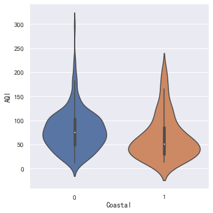

```python
sns.catplot(x='Coastal',y='AQI',kind='violin',data=data)
plt.show()
```

我们可以将散点与箱线图或小提琴图结合在一起进行绘制，下面以小提琴图为例。

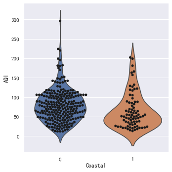

```python
g = sns.catplot(x='Coastal',y='AQI',kind='violin',data=data,inner = None)
sns.catplot(x='Coastal',y='AQI',kind='swarm',data=data,color='k',size = 1,ax = g.ax)
plt.show()
```

这里，我们可以进行双样本t检验，来查看临海城市与内陆城市的均值差异是否显著。

```python
coastal  = data[data['Coastal'] == 1]['AQI']
inland = data[data['Coastal'] == 0]['AQI']

#进行方差齐性检验。为后续的两样本检验服务。

stats.levene(coastal,inland)
```

```
LeveneResult(statistic=0.08825036641952543, pvalue=0.7666054880248168)
```

```python
#进行两样本t检验。注意，两样本的方差相同与不相同，取得的结果是不同的。
stats.ttest_ind(coastal,inland,equal_var=True)
```

```
Ttest_indResult(statistic=-2.7303827520948905, pvalue=0.006675422541012958)
```

```python
# stats.ttest_ind(coastal,inland,equal_var=False)
```

### 空气质量主要受哪些因素影响

我们很可能会关注某些问题，例如，我们可能会产生类似如下的疑问：

- 人口密度大，是否会对空气质量造成负面影响？
- 绿化率高，是否会提高空气质量？

```python
info
```

|  | 列名 | 含义 |
| --- | --- | --- |
| 0 | City | 城市名 |
| 1 | AQI | 空气质量指数 |
| 2 | Precipitation | 降雨量 |
| 3 | GDP | 城市生产总值 |
| 4 | Temperature | 温度 |
| 5 | Longitude | 经度 |
| 6 | Latitude | 纬度 |
| 7 | Altitude | 海拔高度 |
| 8 | PopulationDensity | 人口密度 |
| 9 | Coastal | 是否沿海 |
| 10 | GreenCoverageRate | 绿化覆盖率 |
| 11 | Incineration(10,000ton) | 焚烧量(10000吨) |

#### 绘制散点图矩阵

通过散点图矩阵，可以显示任意两个变量之间的散点图，我们可以通过散点图，观察两个变量之间的关系。

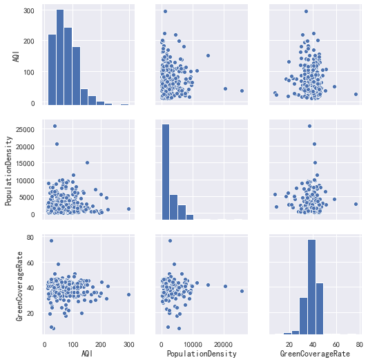

```python
sns.pairplot(data[['AQI','PopulationDensity','GreenCoverageRate']])
```

```python
# sns.catplot(x='GreenCoverageRate',y='AQI',hue = 'GreenCoverageRate',data=data)
```

#### 相关系数

相关系数，可以用来体现两个连续变量之间的相关性，最为常用的为皮尔逊相关系数。其定义公式为：

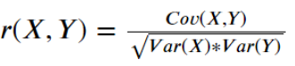

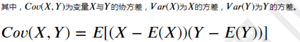

我们以空气质量（AQl）与降雨量（Precipitation）为例，计算二者的相关系数。

```python
x = data["AQI"]
y = data["Precipitation"]
#计算AQI与Precipitation的协方差
a = (x-x.mean()) * (y-y.mean())
cov = np.sum(a) /(len(a) - 1)
print(cov)

corr = cov / np.sqrt(x.var() * y.var())
print(corr)
```

```
-10098.209013903044
-0.40184407003013883
```

```python
#直接使用内置函数进行计算
print(x.cov(y))#协方差
print(x.corr(y))#相关系数
```

```
-10098.20901390304
-0.4018440700301391
```

```python
data.corr()#查看各变量间相关系数
```

|  | AQI | Precipitation | GDP | Temperature | Longitude | Latitude | Altitude | PopulationDensity | Coastal | GreenCoverageRate | Incineration(10,000ton) |
| --- | --- | --- | --- | --- | --- | --- | --- | --- | --- | --- | --- |
| AQI | 1.000000 | -0.401844 | 0.160341 | -0.283956 | 0.093900 | 0.552652 | -0.204753 | -0.026496 | -0.150656 | -0.097734 | 0.106898 |
| Precipitation | -0.401844 | 1.000000 | 0.176665 | 0.685447 | 0.223211 | -0.656175 | -0.324124 | 0.067047 | 0.259783 | 0.153291 | 0.201174 |
| GDP | 0.160341 | 0.176665 | 1.000000 | 0.145780 | 0.173041 | -0.010124 | -0.208952 | 0.229402 | 0.174241 | -0.039220 | 0.899550 |
| Temperature | -0.283956 | 0.685447 | 0.145780 | 1.000000 | 0.141277 | -0.807119 | -0.459426 | 0.144923 | 0.305894 | 0.216575 | 0.173590 |
| Longitude | 0.093900 | 0.223211 | 0.173041 | 0.141277 | 1.000000 | 0.173585 | -0.737548 | -0.121986 | 0.374889 | 0.156439 | 0.072068 |
| Latitude | 0.552652 | -0.656175 | -0.010124 | -0.807119 | 0.173585 | 1.000000 | 0.002571 | -0.167384 | -0.204199 | -0.142776 | -0.081412 |
| Altitude | -0.204753 | -0.324124 | -0.208952 | -0.459426 | -0.737548 | 0.002571 | 1.000000 | -0.031408 | -0.271570 | -0.182449 | -0.122192 |
| PopulationDensity | -0.026496 | 0.067047 | 0.229402 | 0.144923 | -0.121986 | -0.167384 | -0.031408 | 1.000000 | -0.034158 | 0.021197 | 0.283563 |
| Coastal | -0.150656 | 0.259783 | 0.174241 | 0.305894 | 0.374889 | -0.204199 | -0.271570 | -0.034158 | 1.000000 | 0.264419 | 0.158850 |
| GreenCoverageRate | -0.097734 | 0.153291 | -0.039220 | 0.216575 | 0.156439 | -0.142776 | -0.182449 | 0.021197 | 0.264419 | 1.000000 | -0.029088 |
| Incineration(10,000ton) | 0.106898 | 0.201174 | 0.899550 | 0.173590 | 0.072068 | -0.081412 | -0.122192 | 0.283563 | 0.158850 | -0.029088 | 1.000000 |

为了能够更清晰的呈现相关系数值，我们可以使用热图来展示相关系数。

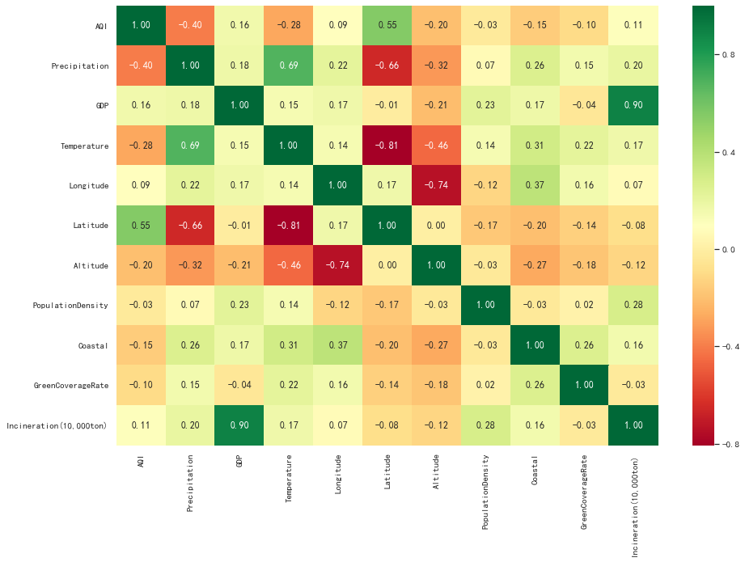

```python
f,aex = plt.subplots(figsize=(15,10))
sns.heatmap(data = data.corr(),annot=True,fmt='.2f',cmap=plt.cm.RdYlGn)#cmap:地图设置图像格式
plt.show()
```

```python
# data.head()
```

```python
# info
```

通过相关系数图可得出，南方城市的空气质量要好于北方城市，西部城市要好于东部城市

#### 结果统计

从结果中可知，空气质量指数主要受降雨量（-0.40）与纬度（0.55）影响。

- 降雨量越多，空气质量越好。
- 纬度越低，空气质量越好。 此外，我们还能够发现其他一些明显的细节：
- GDP（城市生产总值）与Incineration（焚烧量）正相关（0.90）。
- Temperature（温度）与Precipitation（降雨量）正相关（0.69）。
- Temperature（温度）与Latitude（纬度）负相关（-0.81）。
- Longitude（经度）与Altitude（海拔）负相关（-0.74）。
- Latitude（纬度）与Precipitation（降雨量）负相关（-0.66）。
- Temperature（温度）与Altitude（海拔）负相关（-0.46）。
- Altitude（海拔）与Precipitation（降雨量）负相关（-0.32）。

#### 可疑的相关系数值

通过之前的分析，我们得知，临海城市的空气质量，确实好于内陆城市，可是，为什么临海（Coastal）与空气质量指数（AQl）的相关系数（-0.15）并不高呢？

- 分类变量0,1值影响

### 对空气质量指数进行预测

对于某城市，如果我们已知降雨量，温度，经纬度等指标，我们是否能够预测该城市的空气质量指数呢？ 答案是肯定的。我们可以通过对以往的数据，去建立一种模式，然后将这种模式去应用于未知的数据，进而预测结果。

```python
from sklearn.linear_model import LinearRegression
from sklearn.model_selection import train_test_split
```

```python
x = data.drop(['AQI','City'],axis=1)#axis = 1按照列的方向进行删除
y = data['AQI'] #要计算预测的结果

x_train,x_test,y_train,y_test = train_test_split(x,y,test_size = 0.25,random_state = 0)
lr = LinearRegression()
lr.fit(x_train,y_train) #用线性回归模型对数据进行拟合
y_hat = lr.predict(x_test)#计算预测值

print(lr.score(x_train,y_train))
print(lr.score(x_test,y_test))
# print(y_hat)
```

```
0.4685357478390665
0.30759980354175087
```

```python
# y.head()
```

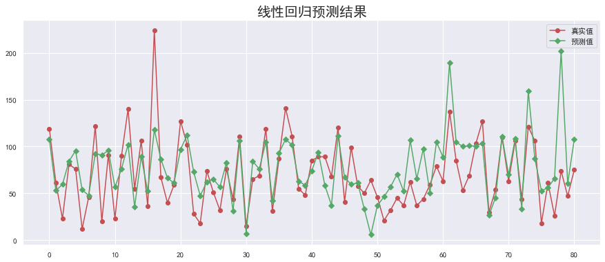

```python
# y_test.count()
plt.figure(figsize=(15,6))
plt.plot(y_test.values,'-r',label="真实值",marker = 'o')
plt.plot(y_hat,'-g',label = "预测值",marker = 'D')
plt.legend()
plt.title("线性回归预测结果",fontsize=20)
plt.show()
```

```python
y_test.values
```

```
array([119,  61,  23,  81,  76,  12,  46, 122,  20,  91,  23,  90, 140,
        55, 106,  36, 224,  67,  40,  59, 127, 102,  28,  18,  74,  51,
        32,  76,  44, 111,  15,  65,  69, 119,  31,  87, 141, 111,  55,
        48,  85,  89,  89,  68, 120,  41,  99,  58,  50,  64,  46,  21,
        32,  45,  37,  62,  37,  44,  59,  79,  63, 137,  85,  53,  69,
       103, 127,  30,  54, 110,  63, 106,  44, 121, 106,  18,  61,  26,
        74,  47,  75], dtype=int64)
```

```python
len(y_test)
```

```
81
```

```python
y_test.values
```

```
array([119,  61,  23,  81,  76,  12,  46, 122,  20,  91,  23,  90, 140,
        55, 106,  36, 224,  67,  40,  59, 127, 102,  28,  18,  74,  51,
        32,  76,  44, 111,  15,  65,  69, 119,  31,  87, 141, 111,  55,
        48,  85,  89,  89,  68, 120,  41,  99,  58,  50,  64,  46,  21,
        32,  45,  37,  62,  37,  44,  59,  79,  63, 137,  85,  53,  69,
       103, 127,  30,  54, 110,  63, 106,  44, 121, 106,  18,  61,  26,
        74,  47,  75], dtype=int64)
```

之所以线性回归模型拟合的效果不好，是因为数据在高维空间中，并没有呈现线性关系，我们从相关系数中，就可以清楚的看到这点。

```python
#用随机森林模型进行预测
from sklearn.ensemble import RandomForestRegressor
rf = RandomForestRegressor(n_estimators=500,random_state=0)
rf.fit(x_train,y_train)

y_hat = rf.predict(x_test)

print(rf.score(x_train,y_train))
print(rf.score(x_test,y_test))
```

```
0.9375592254941046
0.6106531491491578
```

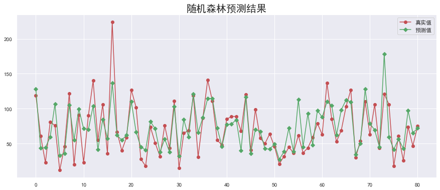

```python
# y_test.count()
plt.figure(figsize=(15,6))
plt.plot(y_test.values,'-r',label="真实值",marker = 'o')
plt.plot(y_hat,'-g',label = "预测值",marker = 'D')
plt.legend()
plt.title("随机森林预测结果",fontsize=20)
plt.show()
```